# Презентация по лабораторной работе №6

Поиск файлов. Перенаправление ввода-вывода. Просмотр запущенных процессов

Сагдеров Камал

Российский университет дружбы народов, Москва, Россия

14.03.2023

## Цель работы

Ознакомление с инструментами поиска файлов и фильтрации текстовых данных. Приобретение практических навыков: по управлению процессами (и заданиями), по проверке использования диска и обслуживанию файловых систем

## Основные задачи

1. Осуществите вход в систему, используя соответствующее имя пользователя.
2. Запишите в файл file.txt названия файлов, содержащихся в каталоге /etc. Допишите в этот же файл названия файлов, содержащихся в вашем домашнем каталоге.
3. Выведите имена всех файлов из file.txt, имеющих расширение .conf, после чего запишите их в новый текстовой файл conf.txt.

## Основные задачи

4. Определите, какие файлы в вашем домашнем каталоге имеют имена, начинавшиеся с символа c? Предложите несколько вариантов, как это сделать.
5. Выведите на экран (по странично) имена файлов из каталога /etc, начинающиеся с символа h.
6. Запустите в фоновом режиме процесс, который будет записывать в файл ~/logfile файлы, имена которых начинаются с log.
7. Удалите файл ~/logfile.

## Основные задачи

8. Запустите из консоли в фоновом режиме редактор gedit.
9. Определите идентификатор процесса gedit, используя команду ps, конвейер и фильтр grep. Как ещё можно определить идентификатор процесса?
10. Прочтите справку (man) команды kill, после чего используйте её для завершения процесса gedit.
11. Выполните команды df и du, предварительно получив более подробную информацию об этих командах, с помощью команды man.
12. Воспользовавшись справкой команды find, выведите имена всех директорий, имеющихся в вашем домашнем каталоге.

## Процесс выполнения

1. Запишим в файл file.txt названия файлов, содержащихся в каталоге /etc. Допи- шим в этот же файл названия файлов, содержащихся в нашем домашнем каталоге

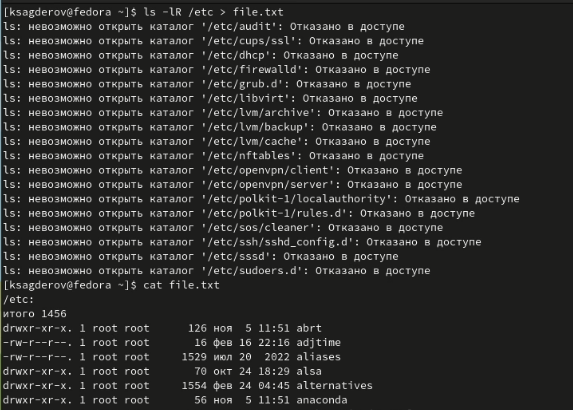

Запись названий файлов из каталога /etc в файл file.txt

## Процесс выполнения

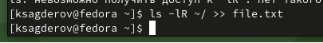

Запись названий файлов из домашнего каталога в файл file.txt

## Процесс выполнения

2. Выведим имена всех файлов из file.txt, имеющих расширение .conf, после чего запишим их в новый текстовой файл conf.txt

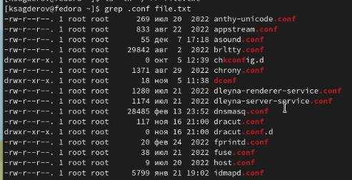

Вывод всех имен с расширением .conf

## Процесс выполнения

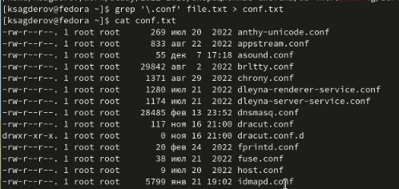

Запись этих имен в файл conf.txt

## Процесс выполнения

3. Определим, какие файлы в нашем домашнем каталоге имеют имена, начинавшиеся с символа c? Предложим несколько вариантов, как это сделать

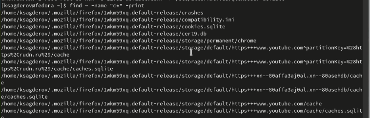

Команда find

## Процесс выполнения

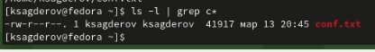

Команда grep

## Процесс выполнения

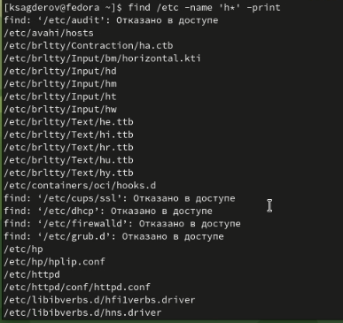

имена файлов из каталога /etc, начинающиеся с символа h

## Процесс выполнения

5. Запустим в фоновом режиме процесс, который будет записывать в файл ~/logfile файлы, имена которых начинаются с log

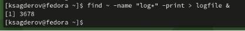

Запуск в фоновом режиме

## Процесс выполнения

6. Удалим файл ~/logfile

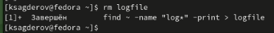

Удаление файла ~/logfile

## Процесс выполнения

7. Запустим из консоли в фоновом режиме редактор gedit

## Процесс выполнения

8. Определим идентификатор процесса gedit, используя команду ps, конвейер и фильтр grep

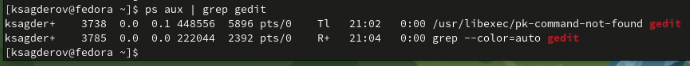

## Процесс выполнения

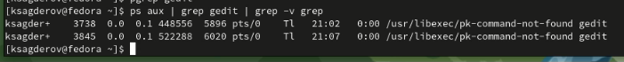

Второй способ определения идентификатора процесса gedit

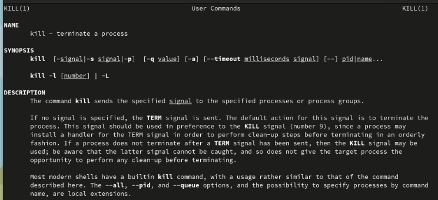

Справка man kill

## Процесс выполнения

10. Выполним команды df и du, предварительно получив более подробную информацию об этих командах, с помощью команды man

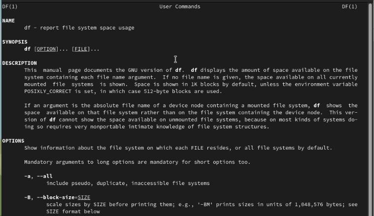

Команда man df

## Процесс выполнения

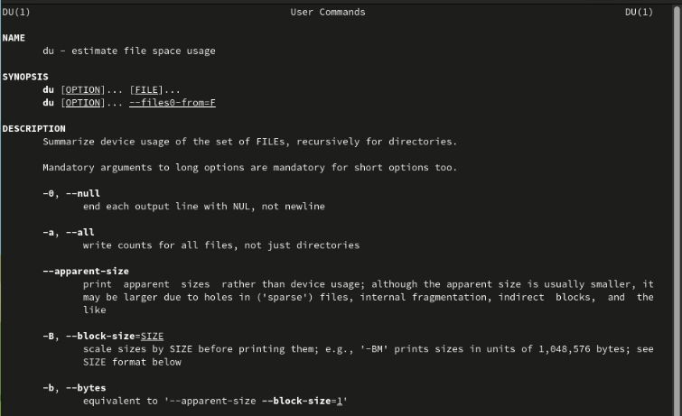

Команда man du

## Процесс выполнения

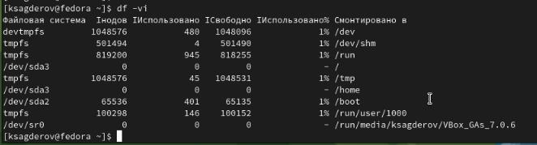

Команда df -vi

## Процесс выполнения

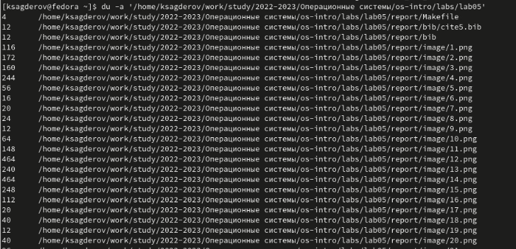

Команда du -a

## Процесс выполнения

11. Воспользовавшись справкой команды find, выведим имена всех директорий, имеющихся в нашем домашнем каталоге

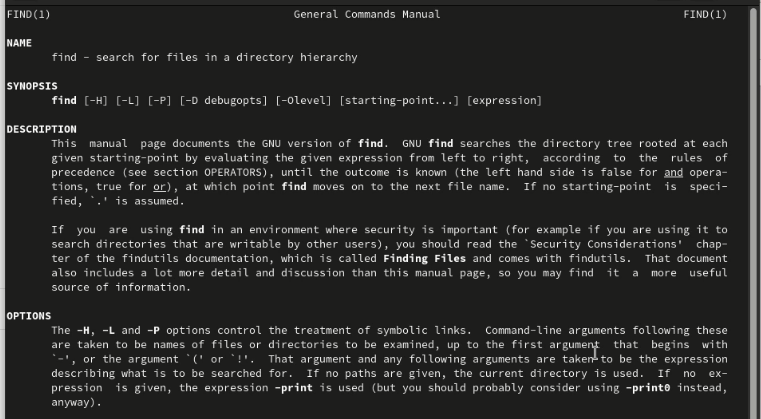

Команда man find

## Процесс выполнения

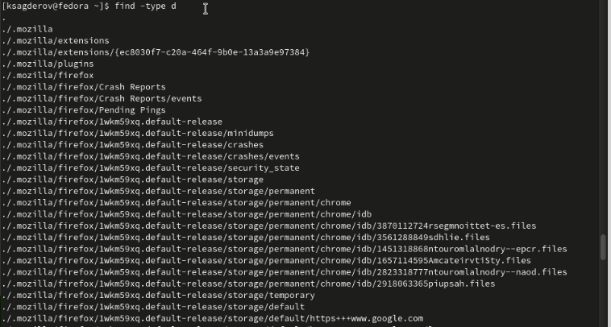

Команда find -type d

## Выводы

В процессе выполнения лабораторной работы я ознакомился с инструментами поиска файлов и фильтрации текстовых данных. Приобрел практические навыки по управлению процессами и обслуживанию файловых систем.

# Спасибо за внимание!